# Exploratory Data Analysis on Red Wine Data by Ramon Joseph P. Esteves

# Univariate Plots Section

```
##  fixed.acidity   volatile.acidity  citric.acid    residual.sugar
##  Min.   : 4.60   Min.   :0.1200   Min.   :0.000   Min.   : 0.900
##  1st Qu.: 7.10   1st Qu.:0.3900   1st Qu.:0.090   1st Qu.: 1.900
##  Median : 7.90   Median :0.5200   Median :0.260   Median : 2.200
##  Mean   : 8.32   Mean   :0.5278   Mean   :0.271   Mean   : 2.539
##  3rd Qu.: 9.20   3rd Qu.:0.6400   3rd Qu.:0.420   3rd Qu.: 2.600
##  Max.   :15.90   Max.   :1.5800   Max.   :1.000   Max.   :15.500
##    chlorides       free.sulfur.dioxide total.sulfur.dioxide
##  Min.   :0.01200   Min.   : 1.00       Min.   :  6.00
##  1st Qu.:0.07000   1st Qu.: 7.00       1st Qu.: 22.00
##  Median :0.07900   Median :14.00       Median : 38.00
##  Mean   :0.08747   Mean   :15.87       Mean   : 46.47
##  3rd Qu.:0.09000   3rd Qu.:21.00       3rd Qu.: 62.00
##  Max.   :0.61100   Max.   :72.00       Max.   :289.00
##     density             pH          sulphates         alcohol
##  Min.   :0.9901   Min.   :2.740   Min.   :0.3300   Min.   : 8.40
##  1st Qu.:0.9956   1st Qu.:3.210   1st Qu.:0.5500   1st Qu.: 9.50
##  Median :0.9968   Median :3.310   Median :0.6200   Median :10.20
##  Mean   :0.9967   Mean   :3.311   Mean   :0.6581   Mean   :10.42
##  3rd Qu.:0.9978   3rd Qu.:3.400   3rd Qu.:0.7300   3rd Qu.:11.10
##  Max.   :1.0037   Max.   :4.010   Max.   :2.0000   Max.   :14.90
##     quality
##  Min.   :3.000
##  1st Qu.:5.000
##  Median :6.000
##  Mean   :5.636
##  3rd Qu.:6.000
##  Max.   :8.000
```

There are eleven input variables and an output variable.

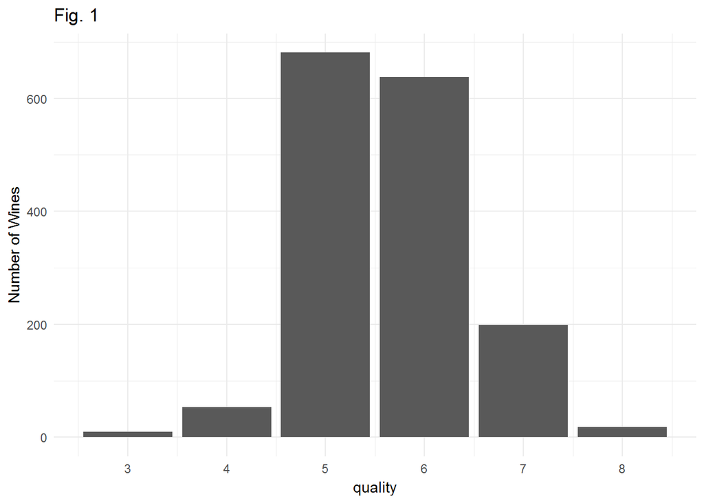

The distribution of the score of the wines looks heavy on the center.

```
##           Bad  Slightly Bad Slightly Good          Good
##            63           681           638           217
```

The new values of the transformed taste quality.

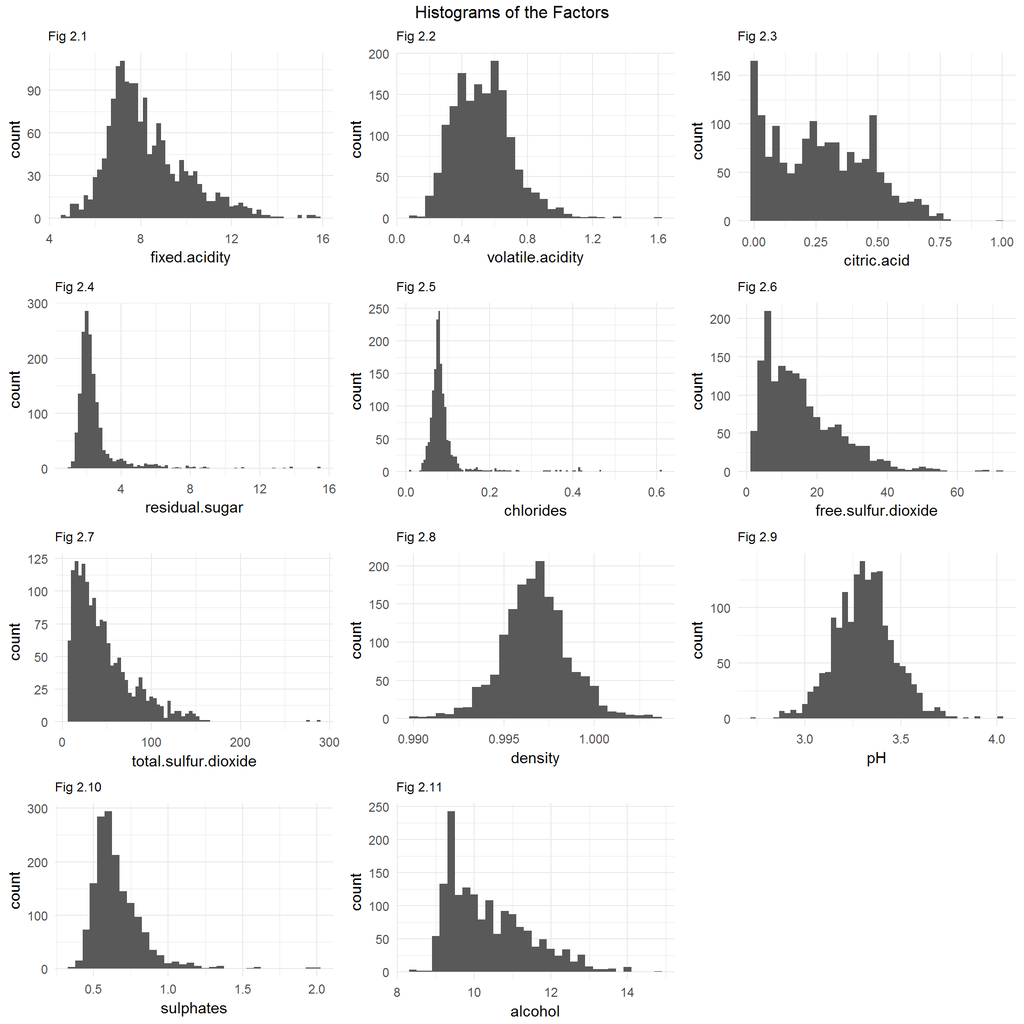

We can see many outliers which we should get rid of.

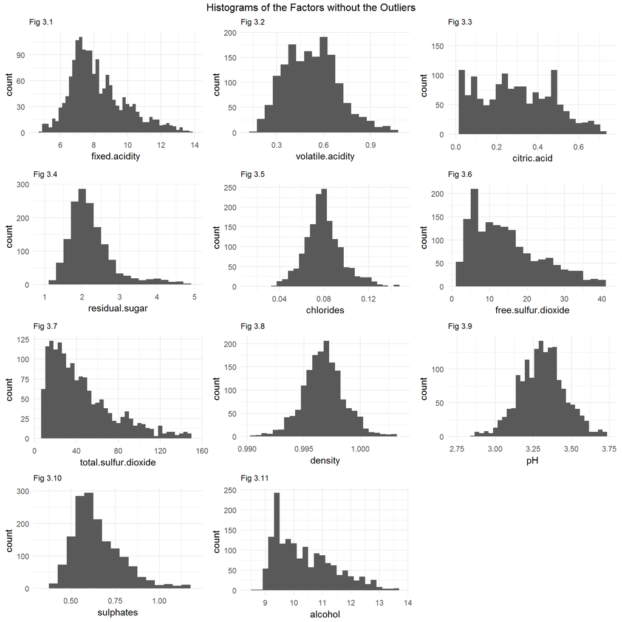

We removed the outliers. Some of the distributions are bell-shaped.

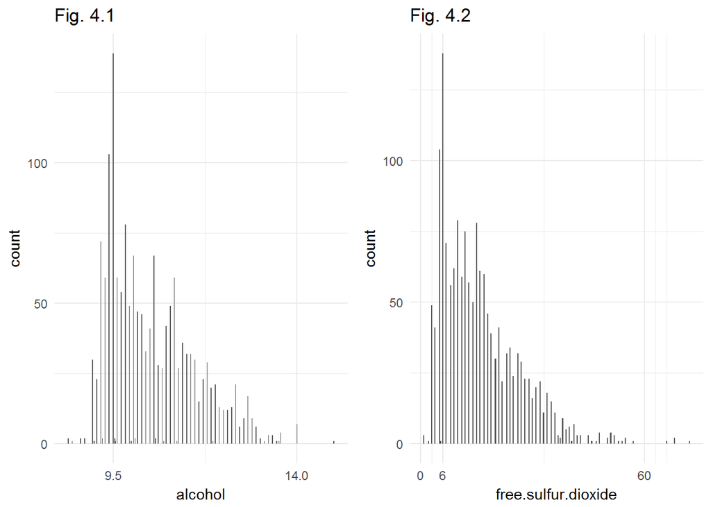

We take a look at the distributions of alcohol and free sulfur dioxide with less binwidth. It is clear that the peak falls at 9.5% and 6 mg/dm^3 for alcohol and free sulfur dioxide, respectively.

# Univariate Analysis

### What is the structure of your dataset?

Our data consists of eleven chemical factors and an output variable which is the score of a wine based on sensory data. The chemicals are the following (based on physicochemical tests):

1. fixed acidity (tartaric acid - g / dm^3): most acids involved with wine or fixed or nonvolatile (do not evaporate readily)
2. volatile acidity (acetic acid - g / dm^3): the amount of acetic acid in wine, which at too high of levels can lead to an unpleasant, vinegar taste
3. citric acid (g / dm^3): found in small quantities, citric acid can add ‘freshness’ and flavor to wines
4. residual sugar (g / dm^3): the amount of sugar remaining after fermentation stops, it’s rare to find wines with less than 1 gram/liter and wines with greater than 45 grams/liter are considered sweet
5. chlorides (sodium chloride - g / dm^3): the amount of salt in the wine
6. free sulfur dioxide (mg / dm^3): the free form of SO2 exists in equilibrium between molecular SO2 (as a dissolved gas) and bisulfite ion; it prevents microbial growth and the oxidation of wine
7. total sulfur dioxide (mg / dm^3): amount of free and bound forms of S02; in low concentrations, SO2 is mostly undetectable in wine, but at free SO2 concentrations over 50 ppm, SO2 becomes evident in the nose and taste of wine
8. density (g / cm^3): the density of water is close to that of water depending on the percent alcohol and sugar content
9. pH: describes how acidic or basic a wine is on a scale from 0 (very acidic) to 14 (very basic); most wines are between 3-4 on the pH scale
10. sulphates (potassium sulphate - g / dm3): a wine additive which can contribute to sulfur dioxide gas (S02) levels, wich acts as an antimicrobial and antioxidant
11. alcohol (% by volume): the percent alcohol content of the wine
12. quality (score between 0 and 10): Output variable (based on sensory data):

The quality in the data (*Fig. 1*) only have values from 3 to 8. And from the distribution, we can see that there are only very few 3’s and 8’s, so let us group them with 4 and 7, respectively. There will now be four groups and we label them as bad, slightly bad, slightly good, and good.

From the distribution of the chemical variables (*Fig. 2.1 - 2.11*), we can see some outliers, especially for volatile acidity, citric acid, residual sugar, chlorides, free sulfur dioxide, total sulfur dioxide and sulphates. We omit those outliers from all of the plots in this report. The resulting distributions are *Fig. 3.1 - 3.11*

### What is/are the main feature(s) of interest in your dataset?

At first glance, before we make any analysis and by just reading the descriptions, each of the eleven variables looks equally important to the taste of a red wine. What we would like to investigate is if it really is the case. It is also our interest to know in what way does a certain factor affect the taste quality of a red wine, if it is indeed significant. For instance, fixed acidity, volatile acidity, residual sugar, chlorides, density, pH and sulphates seem to resemble normal distribution based on their histograms (*Fig. 3.1, 3.2, 3.4, 3.5, 3.8, 3.9, and 3.10*, respectively) . What would be the taste quality on their tails? Or in their means?

It is equally interesting that there is a high peak at 9.5% alcohol content and at 6 mg/dm^3 of free sulfur dioxide (*Fig. 4.1* and *Fig. 4.2*, respectively). We will definitely look for the usual taste quality on those levels.

### What other features in the dataset do you think will help support your investigation into your feature(s) of interest?

It would also be interesting to look at how the input variables are related to each other. Pearson’s correlation is one way, but scatter plots will still be a lot of help to look for non linear relationships. It can help us to do clustering that would be benificial if we are already on the modelling part.

### Did you create any new variables from existing variables in the dataset?

Aside from regrouping the quality of redwines, no other metrics are created in this data set.

### Of the features you investigated, were there any unusual distributions? Did you perform any operations on the data to tidy, adjust, or change the form of the data? If so, why did you do this?

There is no need for any transformations as each of the variables already looked dispersed (*Fig. 3.1 - 3.11*). The taste scores are heavy on the middle, 5 and 6 (*Fig. 1*). We already renamed them to slightly bad and slightly good, repectively. This means that most of the wines taste just “normal”. And the data is already clean enough so it is ready to use for an analysis.

# Bivariate Plots Section

Median of Factors per Taste Quality

```
##   taste_quality fixed.acidity volatile.acidity citric.acid residual.sugar chlorides
## 1           Bad           7.5             0.68        0.08            2.1     0.080
## 2  Slightly Bad           7.8             0.58        0.23            2.2     0.081
## 3 Slightly Good           7.9             0.49        0.26            2.2     0.078
## 4          Good           8.7             0.37        0.40            2.3     0.073
##   free.sulfur.dioxide total.sulfur.dioxide density   pH sulphates alcohol
## 1                   9                   26 0.99660 3.38      0.56    10.0
## 2                  15                   47 0.99700 3.30      0.58     9.7
## 3                  14                   35 0.99656 3.32      0.64    10.5
## 4                  11                   27 0.99572 3.27      0.74    11.6
```

The median of fixed acidity, citric acid, residual sugar, and sulphates are increasing over the taste quality. While The median of volatile acidity is decreasing. This suggests that those factors might have a significant effect on the taste quality.

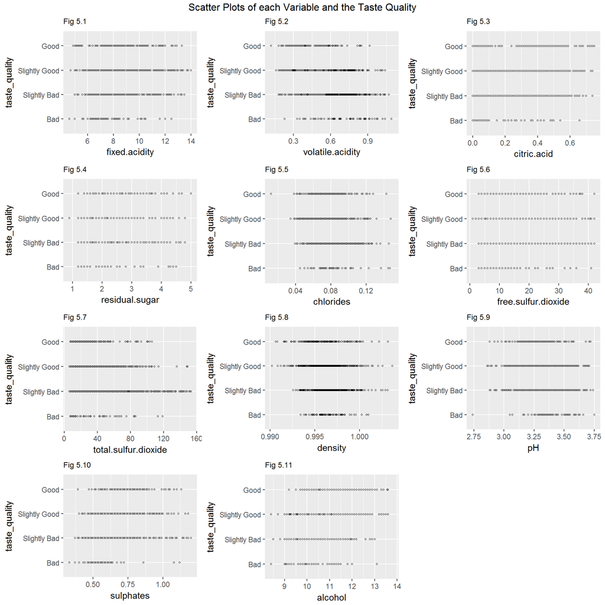

We can see some patterns if we look closely. It will be discussed on the Bivariate Analysis section.

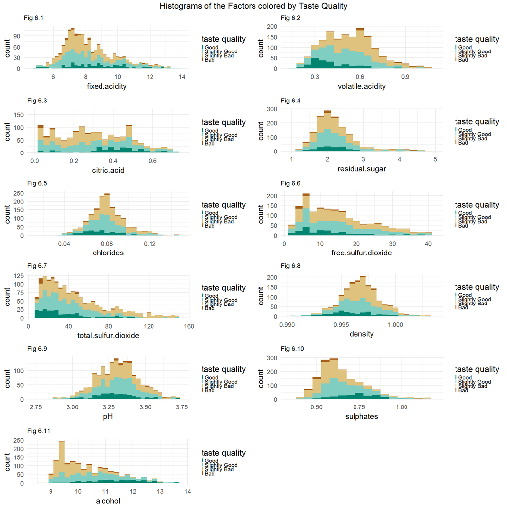

Most of our findings are in this plot section. It is again discussed inthe Bivariate Analysis section.

```
##           fixed volatile citric residual chlorides  free total density    pH sulphates alcohol
## fixed      1.00    -0.26   0.67     0.11      0.09 -0.15 -0.11    0.67 -0.68      0.18   -0.06
## volatile  -0.26     1.00  -0.55     0.00      0.06 -0.01  0.08    0.02  0.23     -0.26   -0.20
## citric     0.67    -0.55   1.00     0.14      0.20 -0.06  0.04    0.36 -0.54      0.31    0.11
## residual   0.11     0.00   0.14     1.00      0.06  0.19  0.20    0.36 -0.09      0.01    0.04
## chlorides  0.09     0.06   0.20     0.06      1.00  0.01  0.05    0.20 -0.27      0.37   -0.22
## free      -0.15    -0.01  -0.06     0.19      0.01  1.00  0.67   -0.02  0.07      0.05   -0.07
## total     -0.11     0.08   0.04     0.20      0.05  0.67  1.00    0.07 -0.07      0.04   -0.21
## density    0.67     0.02   0.36     0.36      0.20 -0.02  0.07    1.00 -0.34      0.15   -0.50
## pH        -0.68     0.23  -0.54    -0.09     -0.27  0.07 -0.07   -0.34  1.00     -0.20    0.21
## sulphates  0.18    -0.26   0.31     0.01      0.37  0.05  0.04    0.15 -0.20      1.00    0.09
## alcohol   -0.06    -0.20   0.11     0.04     -0.22 -0.07 -0.21   -0.50  0.21      0.09    1.00
```

We can see some high correlations within the factors.

# Bivariate Analysis

### Talk about some of the relationships you observed in this part of the investigation. How did the feature(s) of interest vary with other features in the dataset?

The medians of the taste quality of Fixed acidity, citric acid, residual sugar, and sulphates are increasing. And of the four, sulphates had the most gradual increase. It suggests that those factors have a positive effect on the taste.

Next, we try to find the relationship between the taste quality with each of the independent variables (*Fig. 5.1 - 5.11*). As we did earlier, we remove the outliers to take a better picture about what really is going on. At first glance on the scatterplot, we cant see clearly any pattern. But looking closely, we can observe the following:

- There are not so much bad score on the high values of fixed acidity, citric acid, chlorides, free sulfur dioxide, total sulfur dioxide, density, sulphates and alcohol.
- There are not so much bad score on low values of volatile acidity and pH.
- There are not so much good score on the high values o f volatile acidity, chlorides and total sulfur dioxide.
- There are not so much good score on the low values of sulphates and alcohol.

It is also worth mentioning that the peak of the alcohol content, which is at 9.5%, is dominated by slightly bad. While we cannot say any pattern for the peak in free sulfur dioxide.

### What was the strongest relationship you found?

If I am to give a verdict by just looking at these bivariate plots, I would say that in order to have a good quality wine, we choose one with low pH and high Sulphates. Don’t settle for a 9.5% alcohol content, which is what the most red wines have. Instead, choose higher from 11.5% to 13.5%. Keep the Volatile acidity very near the .3 g/dm^3 level. However, this is with the assumption that each factors are independent with each other, which is certainly not. So what we should do is to keep in mind the insights we got from the plots of the factors vs the taste quality, while checking their relationship with each other.

pH has a strong negative correlation with fixed acidity. Fixed acidity has just little impact based on our analysis so far. So **if** by changing fixed acidity there is a causal effect to pH, then wine makers should definitely try to increase the former. Same is true for density and alcohol. Density alone has little effect except for its potential as we stated. But we can look for smaller levels on density if alcohol is unknown. And finally we can try and give a function of citric acid to volatile acidity to look for levels of .3 g/dm^3 of the latter.

# Multivariate Plots Section

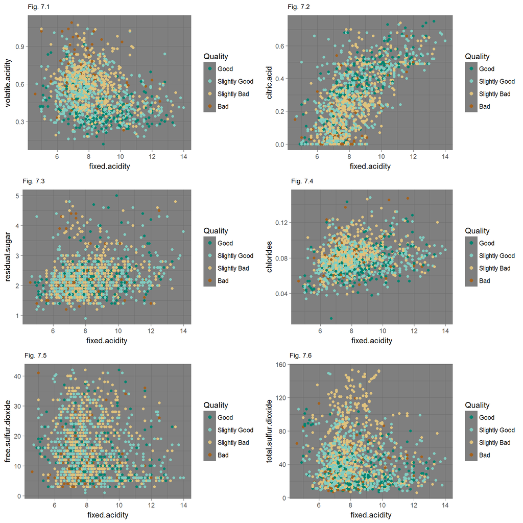

- Quality seems to decrease as volatile acidity increases over fixed acidity. (*Fig. 7.1*)
- Quality seems to increase as citric acid increases over fixed acidity. (*Fig. 7.2*)
- Quality seems to be random over residual sugar and fixed acidity. (*Fig. 7.3*)
- Quality seems to decrease as chlorides increases over fixed acidity. (*Fig. 7.4*)
- Quality seems to be random over free sulfur dioxide and fixed acidity. (*Fig. 7.5*)
- Quality seems to decrease as total sulfur dioxide increases over fixed acidity. (*Fig. 7.6*)

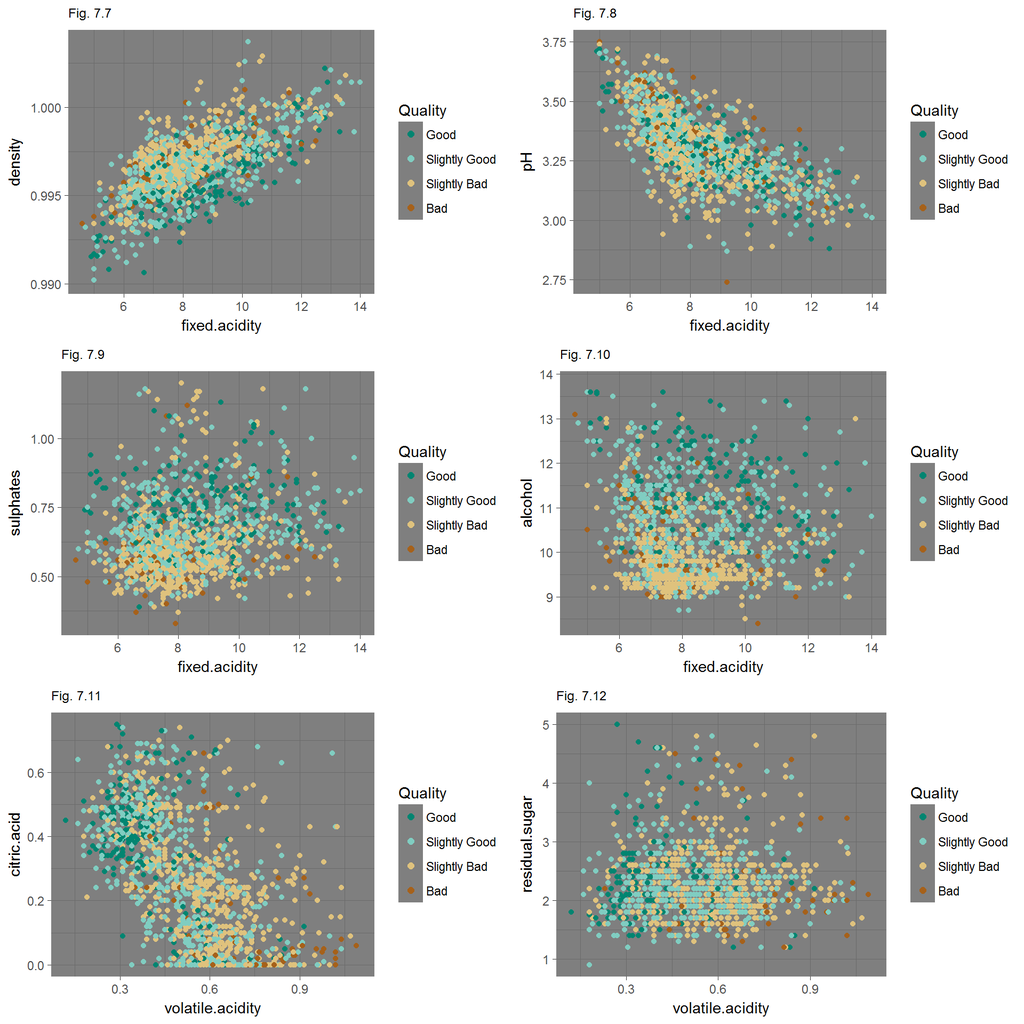

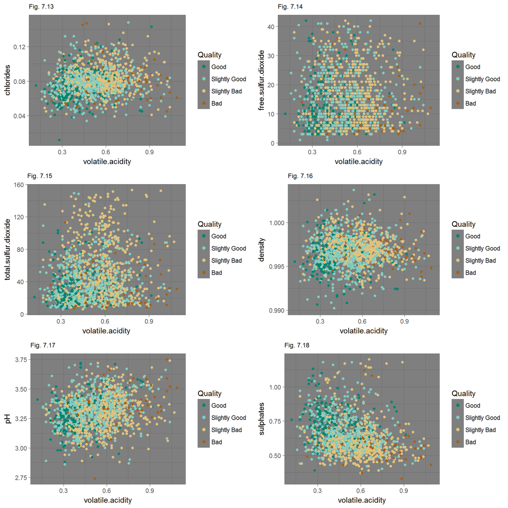

* Quality seems to decrease as volatile acidity and chlorides increase. (*Fig. 7.13*) * Quality seems to decrease as volatile acidity increases over free sulfur dioxide. (*Fig. 7.14*) * Quality seems to decrease as total sulfur dioxide and volatile acidity increase. (*Fig. 7.15*) * Quality seems to decrease as volatile acidity increases over density. (*Fig. 7.16*) * Quality seems to decrease as volatile acidity increases over pH. (*Fig. 7.17*) * Quality seems to decrease as volatile acidity increases and quality seems to increase as sulphates increases. (*Fig. 7.18*)

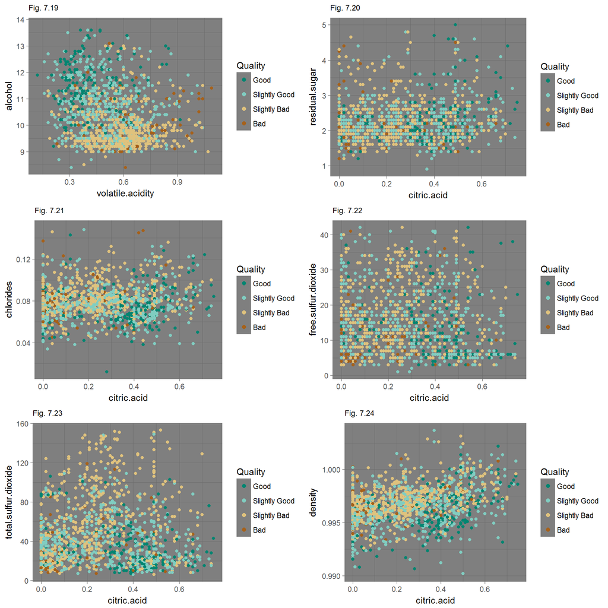

* Quality seems to increase as alcohol increases and quality seems to decrease as volatility increases. (*Fig. 7.19*) * Quality seems to increase as citric acid increases over residual sugar. (*Fig. 7.20*) * Quality seems to increase as citric acid increases over chlorides. (*Fig. 7.21*) * Quality seems to be random over free sulfur dioxide and citric acid. (*Fig. 7.22*) * Quality seems to be random over total sulfur dioxide and citric acid. (*Fig. 7.23*) * Quality seems to be random over density and citric acid. (*Fig. 7.24*)

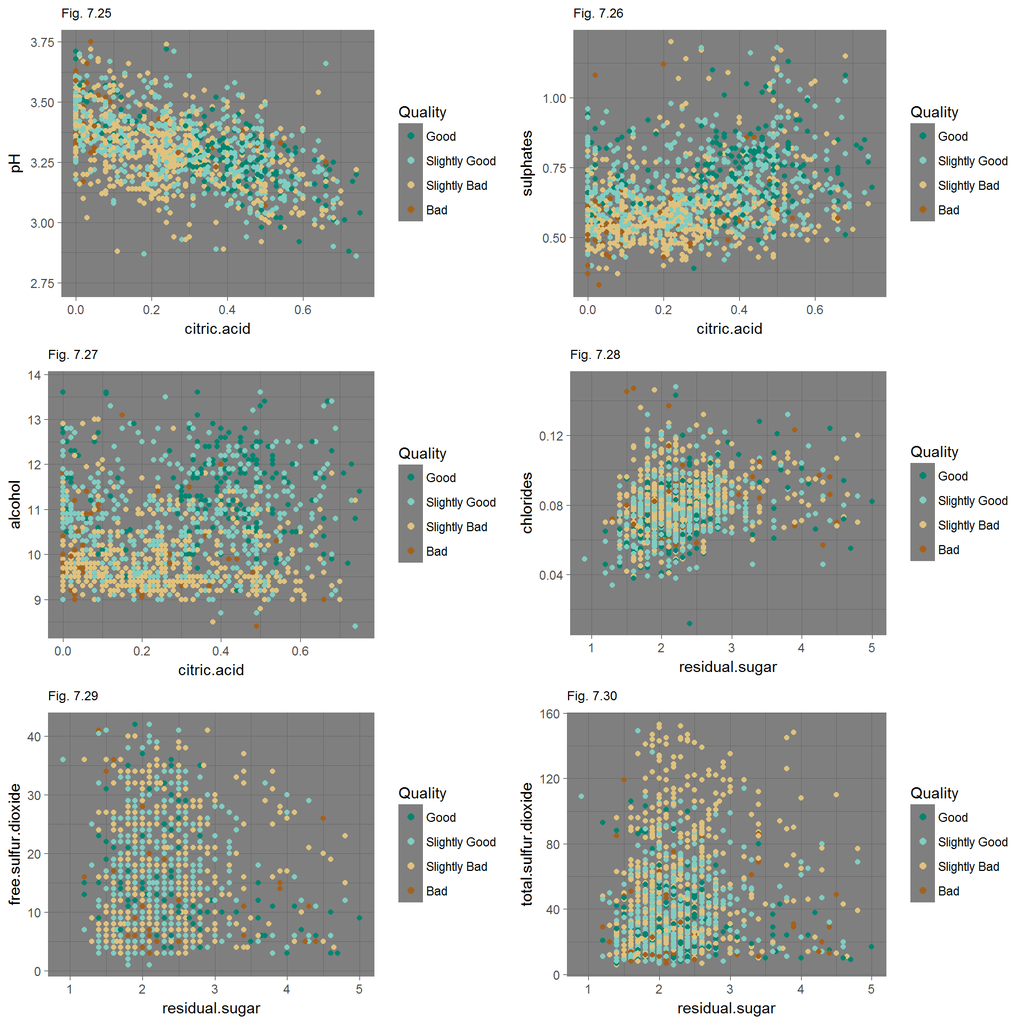

- Quality seems to be random over pH and citric acid. (*Fig. 7.25*)
- Quality seems to increase as sulphates increases over citric acid. (*Fig. 7.26*)
- Quality seems to increase as alcohol increases over citric acid. (*Fig. 7.27*)
- Quality seems to be random over chlorides and residual sugar. (*Fig. 7.28*)
- Quality seems to be random over free sulfur dioxide and residual sugar. (*Fig. 7.29*)
- Quality seems to be random over total sulfur dioxide and residual sugar. (*Fig. 7.30*)

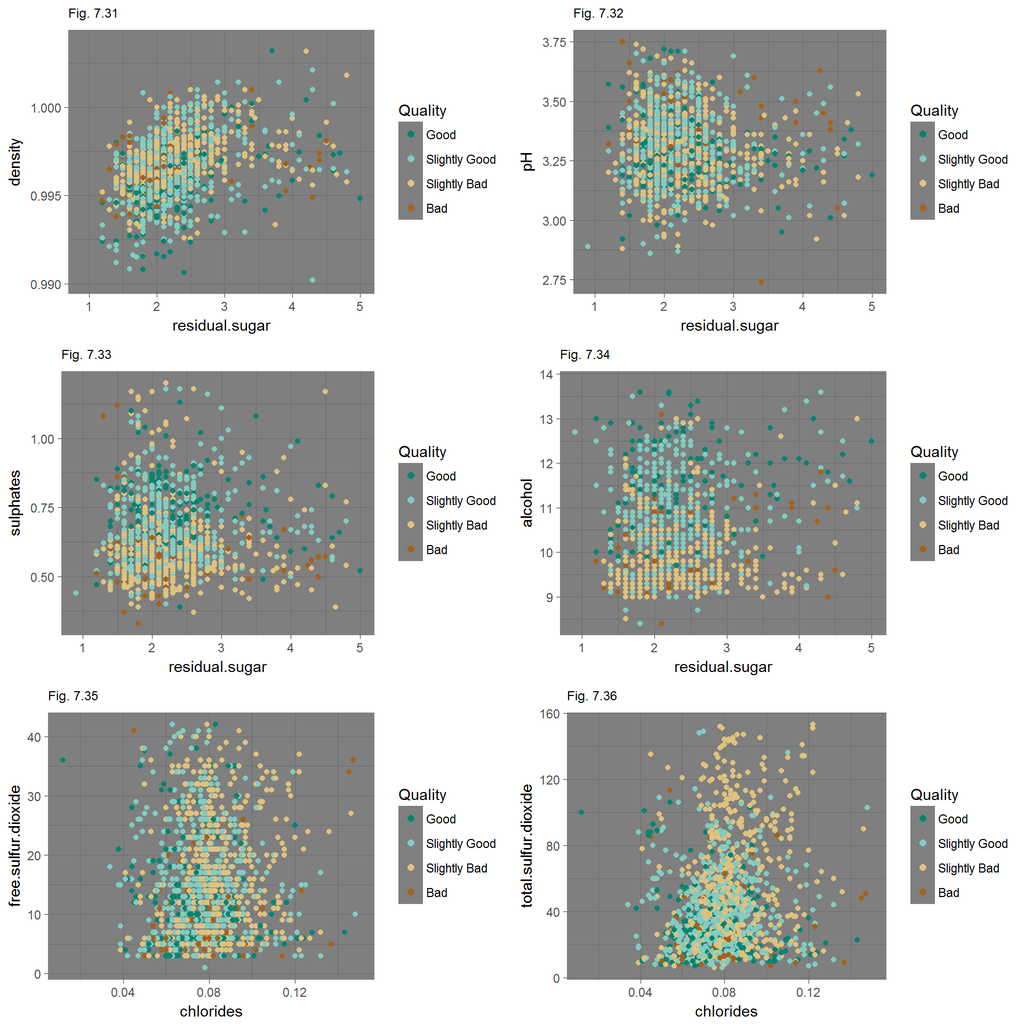

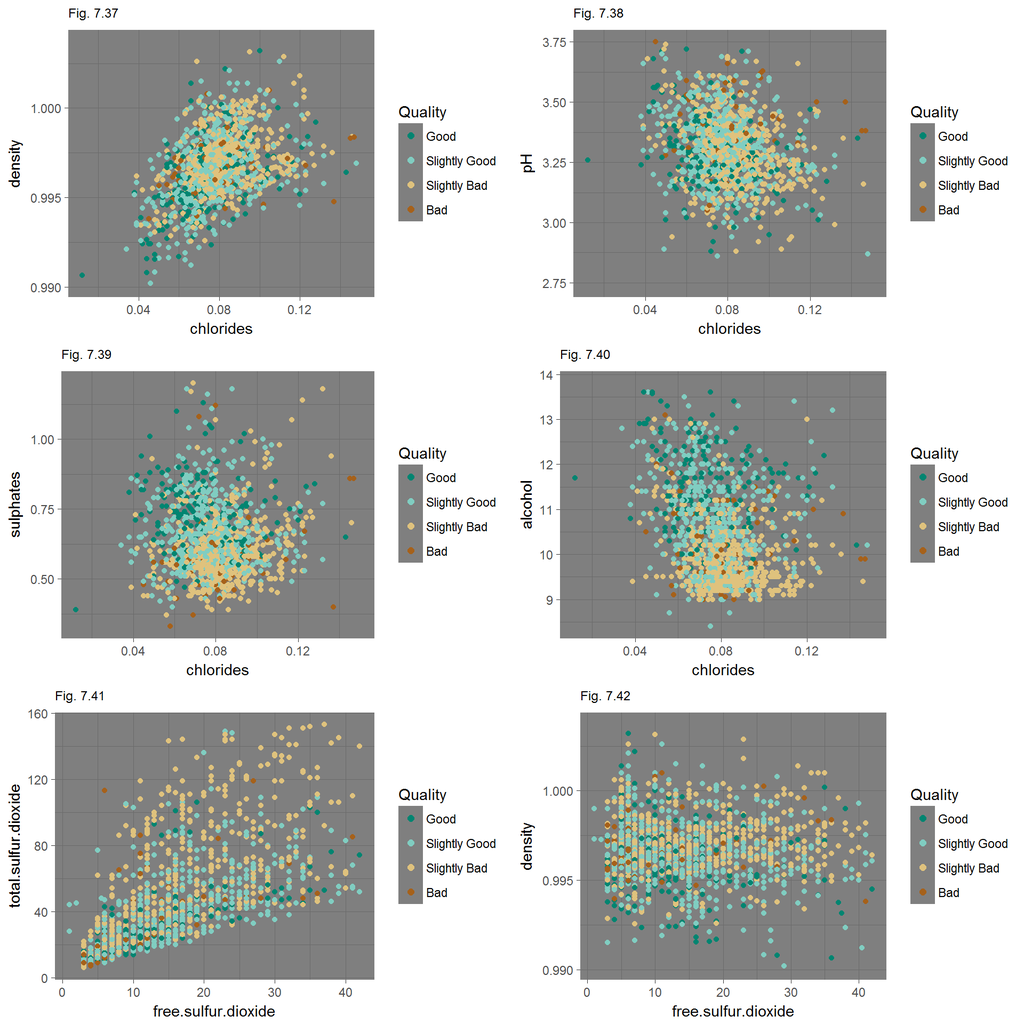

- Quality seems to decrease as chlorides increases over density. (*Fig. 7.37*)
- Quality seems to decrease as pH and chlorides increases. (*Fig. 7.38*)
- Quality seems to decrease as sulphates and chlorides increases. (*Fig. 7.39*)
- Quality seems to decrease as chlorides increases and increase as alcohol increases. (*Fig. 7.40*)
- Quality seems to be random over total sulfur dioxide and free sulfur dioxide. (*Fig. 7.41*)
- Quality seems to decrease as density increases over free sulfur dioxide. (*Fig. 7.42*)

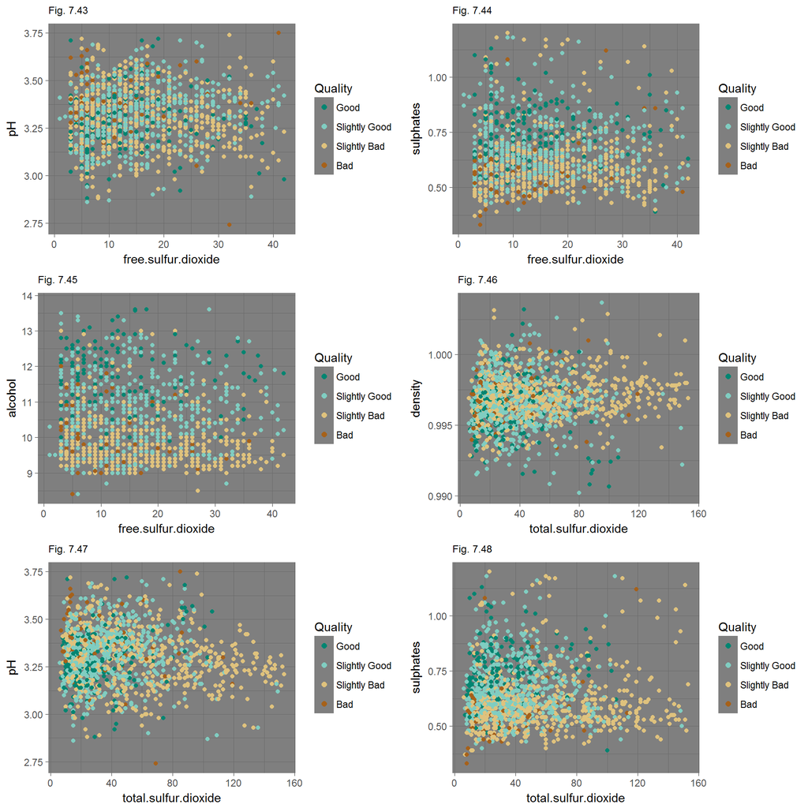

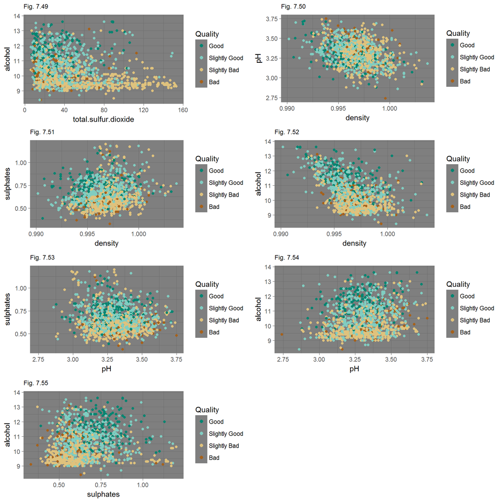

- Quality seems to decrease as total sulfur dioxide increases and increase as alcohol increases. (*Fig. 7.49*)
- Quality seems to decrease as pH increases over density. (*Fig. 7.50*)
- Quality seems to increase as sulphates increases over density. (*Fig. 7.51*)
- Quality seems to increase as alcohol increases over density. (*Fig. 7.52*)
- Quality seems to increase as sulphates increases over pH. (*Fig. 7.53*)
- Quality seems to increase as alcohol increases over pH. (*Fig. 7.54*)
- Quality seems to increase as alcohol and sulphates increase. (*Fig. 7.55*)

# Multivariate Analysis

### Talk about some of the relationships you observed in this part of the investigation. Were there features that strengthened each other in terms of looking at your feature(s) of interest?

For the 55 scatter plots, we will look at the tendency of the quality per factor pairs.

Now this list is a lot. But, we do not need to analyze all of them. We will just focus on the effect of strong relationships from high sulphates and alcohol levels, low pH level, and having a level very near to .3 for volatile acidity. Then why did I still bother on listing all of the relationships of the variables? It is because we might find other observations that I might missed out. So it will be easier to have an analysis when there will be a new observation.

So the plots we will be needing for our current analysis are pH vs fixed acidity (*Fig. 7.8*), density vs alcohol (*Fig. 7.52*), and citric acid vs volatile acidity (*Fig. 7.11*).

### Were there any interesting or surprising interactions between features?

From the three scatter plots that we considered, the linear relationship are all negative. As in our previous analysis, we did not see a pattern on how fixed acidity, density and citric acid impact the score quality. But based on their strong linear and negative relationships with pH, alcohol, and volatile acidity, respectively, we can say that wine drinkers should should choose a higher fixed acidity and citric acid, and a lower density. Chances are better for a good wine quality if they do.

### OPTIONAL: Did you create any models with your dataset? Discuss the strengths and limitations of your model.

I did not create any model for this dataset.

# Final Plots and Summary

### Plot One

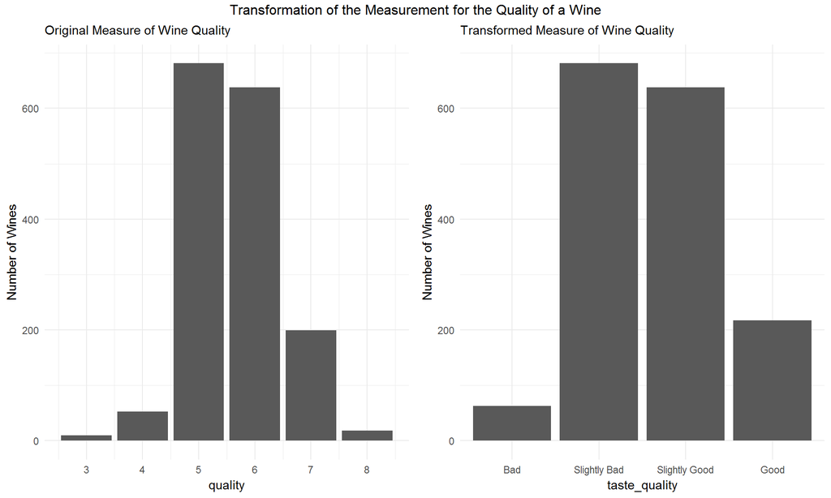

### Description One

When we are already at the part of modelling, it would be difficult to predict for the scores of 3 and 8 since the sample is just very small. It will not lose the accuracy if we just combine them to 4 and 7, respectively. We can all agree that tastes with 3 and 4 are bad scores while tastes with 7 and 8 are good scores. It is also evident that most of the tastes of the wines are in the middle. This fact reduced our exploration significantly as we can just concentrate on looking for the bad and good scores.

### Plot Two

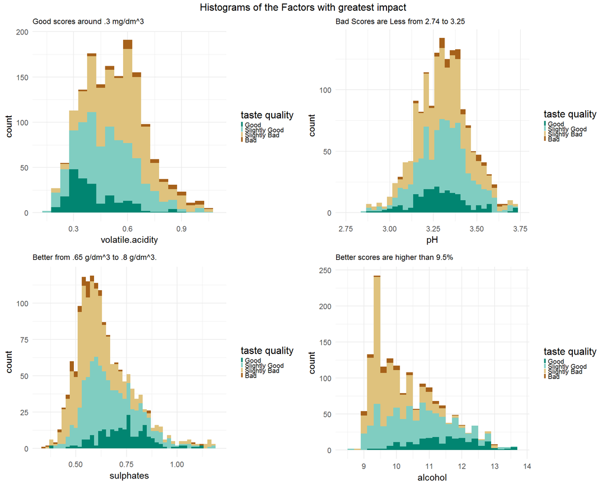

### Description Two

These four factors have the clearest pattern in our analysis. Higher sulphates and alcohol are better, while the reverse is true for pH and volatility. I would like to mention again that most wines have a 9.5% alcohol content, and most of them taste normal. And out of the four, it is the sulphates that have the best pattern. Not only that the good scores are on the range that we stated, bad scores are also less. One important note though, we did not find any evidence that the other seven factors are not important. So let us not dismiss them even if we did not find any clear pattern.

### Plot Three

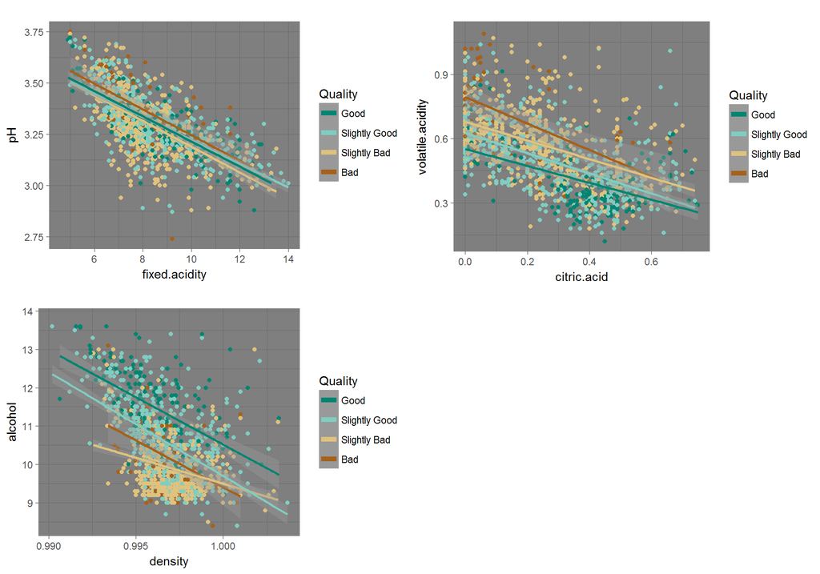

### Description Three

We include the scatter plots of our leading factors and the factors that has a high correlation with them. We have three, as there are no strong linear relationships for sulphates. We included the linear regression lines for each scores to better see the linear relationship of the factors. All of our plots are decreasing. The idea is that we can find ways to look for a better tasting wine even if we do not know the value of the leading factors. For instance, we do not know the pH level of a certain wine but we do know its fixed acidity. So we look at its fixed acidity if it is at levels 12 g/dm^3 to 14 g/dm^3 to avoid having a bad tasting wine.

# Reflection

There are three important points in our analysis:

1. The leading candidates for the wine quality are sulphates, pH, volatile acidity, and alcohol. If we need to determine if a wine is good or not, we should **look for them first** before the other factors. Chances are it will save us time and have a better estimate. If they are unavailable, we can look for the factors that are highly related to them, which are fixed acidity for pH, citric acid for volatile acidity, and density for alcohol.
2. When we are already in the modelling part, **we cannot dismiss the other seven factors** just because we are unable to see a clear pattern for them. It is because we fail to have any evidence that they are not important. So, the model for the taste quality should include all of the eleven factors. Not doing so might give us an incomplete result.
3. **There is a lot of potential** for lower values of Chlorides (.05 g/dm^3 and below) and Density (.990 g/cm^3 to .993 g/cm^3). From the small sample size, the results are great. If it is possible, wine makers can experiment on these values.